# Dodgers Exploratory Data Analysis

İsmail Kaan Özer 22002672, Görkem Kadir Solun 22003214

# Introduction

The Los Angeles Dodgers Baseball team gathered data from their 81 games to analyze. The objective is to increase attendance at the matches. Temperature and Attendance variables are quantitative, while all others are qualitative. The specific analysis target is measuring the effects of all variables on the attendance variable. Below is the summary of the data set.

```r
summary(events)
```

```
##  month         day            attend         day_of_week      opponent
##  APR:12   Min.   : 1.00   Min.   :24312   Monday   :12   Giants   : 9
##  MAY:18   1st Qu.: 8.00   1st Qu.:34493   Tuesday  :13   Padres   : 9
##  JUN: 9   Median :15.00   Median :40284   Wednesday:12   Rockies  : 9
##  JUL:12   Mean   :16.14   Mean   :41040   Thursday : 5   Snakes   : 9
##  AUG:15   3rd Qu.:25.00   3rd Qu.:46588   Friday   :13   Cardinals: 7
##  SEP:12   Max.   :31.00   Max.   :56000   Saturday :13   Brewers  : 4
##  OCT: 3                                   Sunday   :13   (Other)  :34
##       temp          skies    day_night   cap     shirt    fireworks bobblehead
##  Min.   :12.00   Clear :62   Day  :15   NO :79   NO :78   NO :67    NO :70
##  1st Qu.:19.00   Cloudy:19   Night:66   YES: 2   YES: 3   YES:14    YES:11
##  Median :23.00
##  Mean   :22.84
##  3rd Qu.:26.00
##  Max.   :35.00
##
```

# Visualizing and Evaluating Different Variables

To observe whether different variables increase attendance, Chi-squared tests, f-tests, and Welch’s Two Sample t-tests were conducted on variables and attendance. To make sure of the result of analysis, we define a linear regression model with all variables to compare with different models afterwards.

```r
lm1 <- lm(attend ~ ., events)
```

## Bobblehead

Firstly, we need to visualize the attendance with bobblehead promotion existence; then, we can decide whether there was a correlation between the attendance and bobblehead promotions.

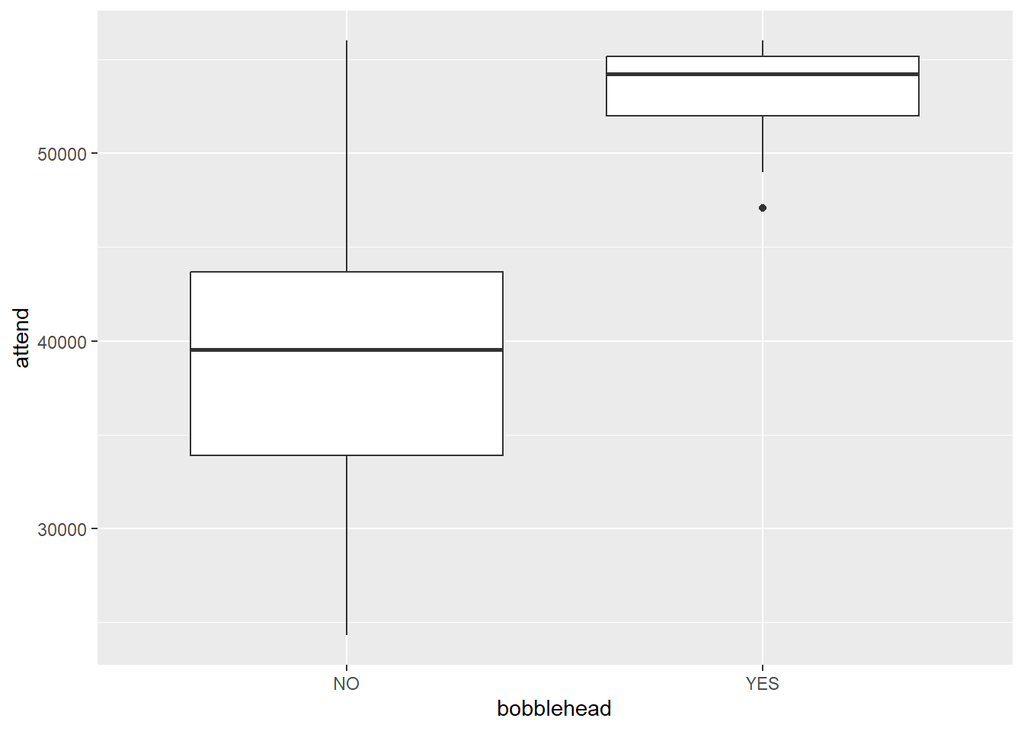

```r
events %>%
  ggplot(aes(bobblehead, attend)) +
  geom_boxplot()
```

The graph suggests that there is a difference. However, to be sure, a Chi-squared test was conducted between attendance and bobblehead promotions.

```r
events %>%
  group_by(bobblehead) %>%
  summarize(avgattend = mean(attend)) %>%
  pull(avgattend) %>% chisq.test()
```

```
##
##  Chi-squared test for given probabilities
##
## data:  .
## X-squared = 2125.9, df = 1, p-value < 2.2e-16
```

Our p-value is near zero, so we can say that bobblehead promotions will increase attendance. The results strongly suggest that bobblehead promotions positively impact attendance. The test showed a clear connection between promotions and attendance numbers.

We can also see how many fans are expected to attend by a bobblehead promotion.

```r
confint(lm1, parm = "bobbleheadYES", level = 0.95)
```

```
##                  2.5 %   97.5 %
## bobbleheadYES 2940.319 15850.95
```

Lastly, we define a linear regression model without bobblehead variable and apply F-test to fully understand that bobblehead is important.

```r
model_wout_bobblehead <- lm(attend ~ month + day + day_of_week + opponent + temp + skies + day_night + cap + shirt + fireworks, data = events)
anova(lm1, model_wout_bobblehead)
```

```
## Analysis of Variance Table
##
## Model 1: attend ~ month + day + day_of_week + opponent + temp + skies +
##     day_night + cap + shirt + fireworks + bobblehead
## Model 2: attend ~ month + day + day_of_week + opponent + temp + skies +
##     day_night + cap + shirt + fireworks
##   Res.Df        RSS Df  Sum of Sq      F   Pr(>F)
## 1     44 1572693825
## 2     45 1880245034 -1 -307551208 8.6045 0.005308 **
## ---
## Signif. codes:  0 '***' 0.001 '**' 0.01 '*' 0.05 '.' 0.1 ' ' 1
```

p-value resulted less than 0.01: A low p-value suggests that there is a significant difference between the two models because null hypothesis suggests that there is no difference. Since there is a significant difference between two models, we can not ignore bobblehead variable because it is important for our model. Now, we are sure that bobblehead promotions increase the attendance.

## Fireworks

Like the bobblehead, firstly, we need to visualize the attendance with the fireworks’ existence, and then we can decide whether there was a correlation between the attendance and fireworks.

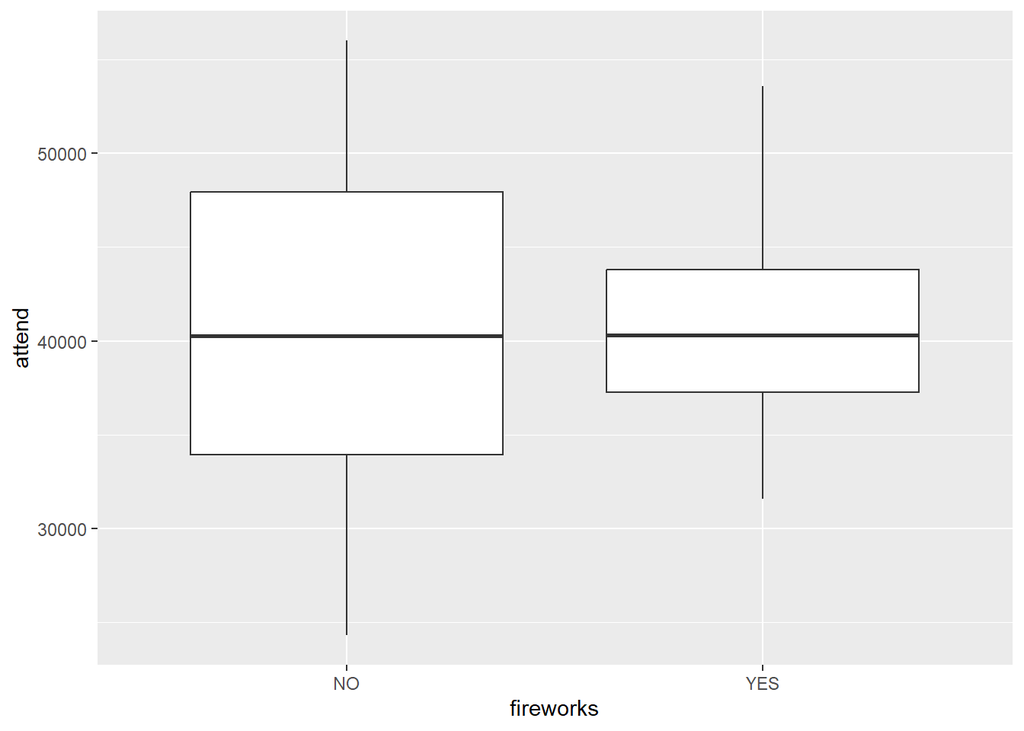

```r
events %>%
  ggplot(aes(fireworks, attend)) +
  geom_boxplot()
```

In contrast to bobbleheads, the graph suggests that there is no difference. However, to be sure, the Welch Two Sample t-test and Chi-squared test was conducted between attendance and fireworks.

```r
t.test(x=events$attend[events$fireworks=="YES"], y=events$attend[events$fireworks=="NO"])
```

```
##
##  Welch Two Sample t-test
##
## data:  events$attend[events$fireworks == "YES"] and events$attend[events$fireworks == "NO"]
## t = 0.024331, df = 27.332, p-value = 0.9808
## alternative hypothesis: true difference in means is not equal to 0
## 95 percent confidence interval:
##  -3804.144  3895.500
## sample estimates:
## mean of x mean of y
##  41077.86  41032.18
```

A statistical test (t-test) was done, and the results suggest that fireworks have little to no impact on attendance. It is seen that there is enough evidence to conclude that there isn’t a relation between attendance and fireworks, considering the p-value of the test is almost 1. The test showed no connection between fireworks and attendance numbers.

A Chi-squared test was also conducted to double check whether there is a connection between fireworks and attendance numbers.

```r
events %>%
  group_by(fireworks) %>%
  summarize(avgattend = mean(attend)) %>%
  pull(avgattend) %>% chisq.test()
```

```
##
##  Chi-squared test for given probabilities
##
## data:  .
## X-squared = 0.025411, df = 1, p-value = 0.8733
```

Similar to the previous test, the results suggest that firework shows have little to no impact on attendance. The test showed no apparent connection between fireworks and attendance numbers. Our p-value is near one, meaning we are confident that fireworks are unrelated to attendance.

## Shirt

Firstly, we need to visualize the attendance with shirt promotion existence, and then we can decide whether there is a correlation between attendance and shirt promotions.

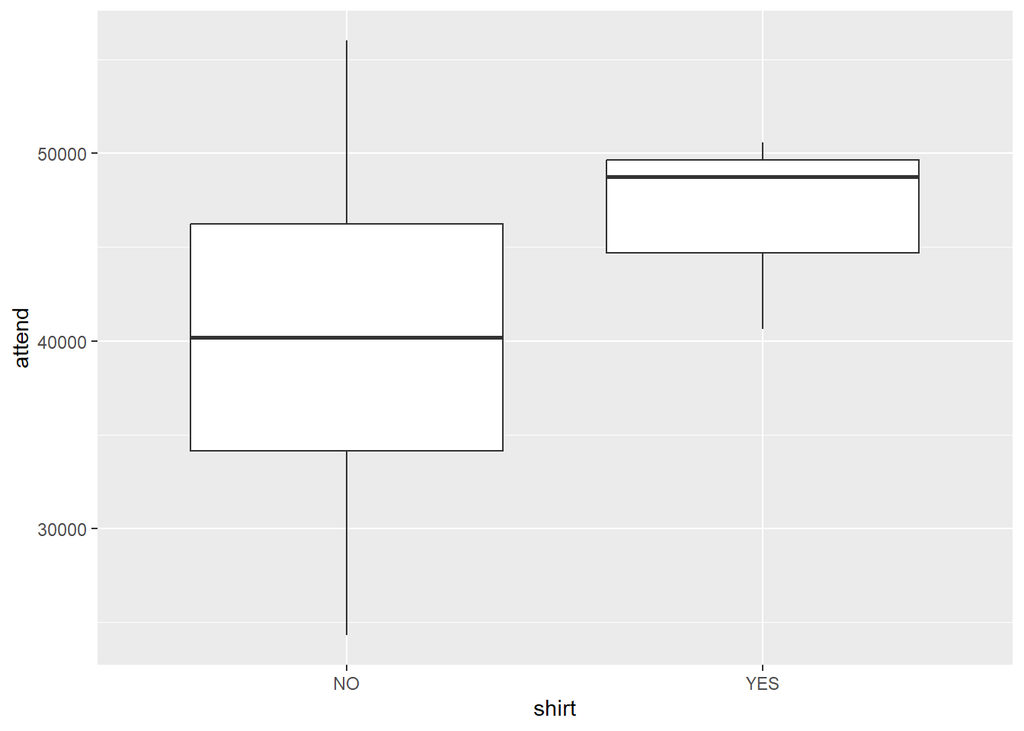

```r
events %>%
  ggplot(aes(shirt, attend)) +
  geom_boxplot()
```

The graph very strongly suggests that there is a difference. However, again, to be sure, a Chi-squared test was also conducted to check whether there is a connection between shirt promotions and attendance numbers.

```r
events %>%
  group_by(shirt) %>%
  summarize(avgattend = mean(attend)) %>%
  pull(avgattend) %>% chisq.test()
```

```
##
##  Chi-squared test for given probabilities
##
## data:  .
## X-squared = 387.14, df = 1, p-value < 2.2e-16
```

The results strongly suggest that shirt promotions positively impact attendance. The test showed a connection between shirt promotions and attendance numbers. Our p-value is near zero, so we are confident that there is difference and shirt promotions will increase attendance.

Therefore, we will focus on our results in Chi-squared tests and consider shirt relations in attendance.

## Cap

Firstly, we need to visualize the attendance with the existence of cap promotions, and then we can decide whether there is a correlation between attendance and cap promotions.

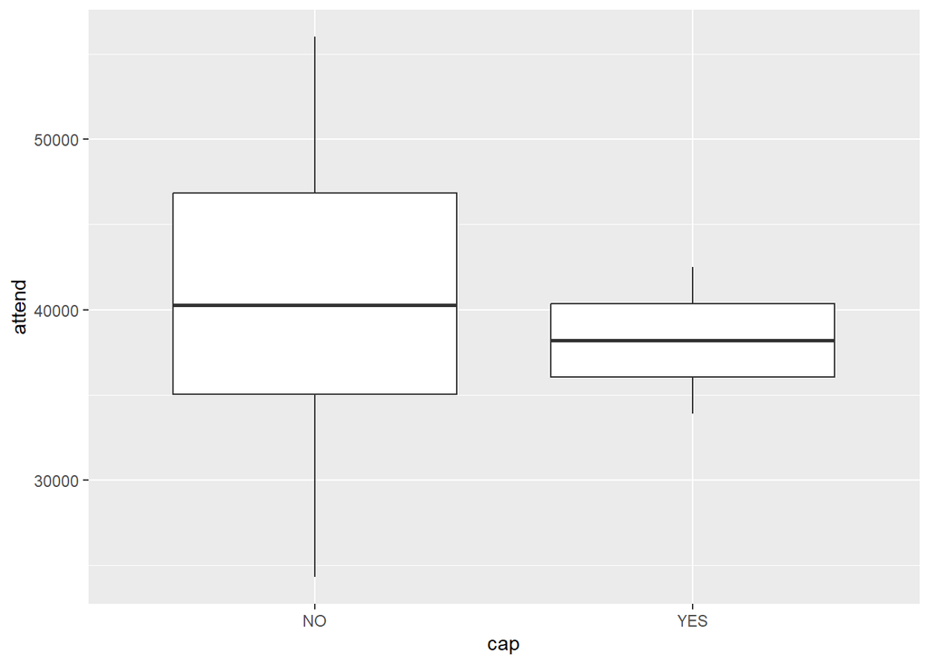

```r
events %>%
  ggplot(aes(cap, attend)) +
  geom_boxplot()
```

The graph suggests that there is a very small difference. However, again, to be sure, a Welch Two Sample t-test was also conducted to check whether there is a connection between cap promotions and attendance numbers.

```r
t.test(x=events$attend[events$cap=='YES'],
       y=events$attend[events$cap=='NO'])
```

```
##
##  Welch Two Sample t-test
##
## data:  events$attend[events$cap == "YES"] and events$attend[events$cap == "NO"]
## t = -0.66319, df = 1.0977, p-value = 0.619
## alternative hypothesis: true difference in means is not equal to 0
## 95 percent confidence interval:
##  -48408.87  42563.39
## sample estimates:
## mean of x mean of y
##  38189.50  41112.24
```

The results suggest that cap promotions have a near to zero impact on attendance. The test showed a disconnection between cap promotions and attendance numbers. Our p-value is more than 0.05, so we are confident that cap promotions is not related to attendance. To make completely sure, anova test is applied.

```r
model_wout_cap <- lm(attend ~ month + day + day_of_week + opponent + temp + skies + day_night + shirt +  fireworks + bobblehead, data = events)
anova(lm1, model_wout_cap)
```

```
## Analysis of Variance Table
##
## Model 1: attend ~ month + day + day_of_week + opponent + temp + skies +
##     day_night + cap + shirt + fireworks + bobblehead
## Model 2: attend ~ month + day + day_of_week + opponent + temp + skies +
##     day_night + shirt + fireworks + bobblehead
##   Res.Df        RSS Df Sum of Sq      F Pr(>F)
## 1     44 1572693825
## 2     45 1616617148 -1 -43923323 1.2289 0.2737
```

Since p-value is higher than 0.05, we are sure that cap promotions are not related to attendance. Therefore, we will not consider cap relations in attendance.

## Day and Night

Firstly, we need to visualize the attendance day and night; then, we can decide whether there was a correlation between the attendance and day or night.

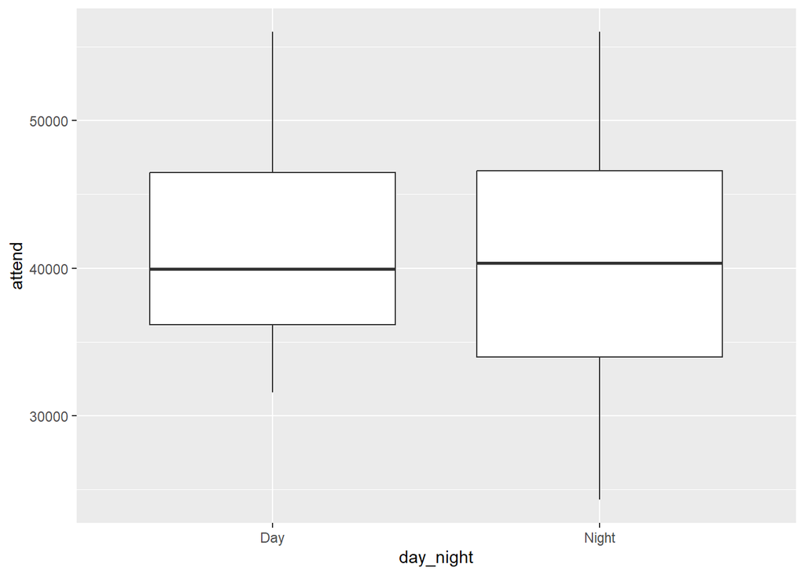

```r
events %>%
  ggplot(aes(day_night, attend)) +
  geom_boxplot()
```

The graph suggests that there is very small to no difference. However, again, to be sure, a Welch Two Sample t-test was conducted to check whether there is a connection between day or night and attendance numbers.

```r
t.test(x=events$attend[events$day_night=='Day'],
       y=events$attend[events$day_night=='Night'])
```

```
##
##  Welch Two Sample t-test
##
## data:  events$attend[events$day_night == "Day"] and events$attend[events$day_night == "Night"]
## t = 0.42851, df = 23.62, p-value = 0.6722
## alternative hypothesis: true difference in means is not equal to 0
## 95 percent confidence interval:
##  -3531.652  5380.397
## sample estimates:
## mean of x mean of y
##  41793.27  40868.89
```

Like the graph, the results suggest that being day or night has no apparent impact on attendance. The test showed a disconnection between being day or night and attendance numbers. Our p-value is more than 0.05, meaning we are confident that being day or night is not related to attendance. Lastly, anova test is applied.

```r
model_wout_time <- lm(attend ~ month + day + day_of_week + opponent + temp + skies + shirt + cap +  fireworks + bobblehead, data = events)
anova(lm1, model_wout_time)
```

```
## Analysis of Variance Table
##
## Model 1: attend ~ month + day + day_of_week + opponent + temp + skies +
##     day_night + cap + shirt + fireworks + bobblehead
## Model 2: attend ~ month + day + day_of_week + opponent + temp + skies +
##     shirt + cap + fireworks + bobblehead
##   Res.Df        RSS Df Sum of Sq      F Pr(>F)
## 1     44 1572693825
## 2     45 1609889783 -1 -37195958 1.0406 0.3132
```

Anova test result suggests that time that game is played does not have a relation with attendance because p value is greater than 0.05. Therefore, we will not consider day and night relations in attendance.

## Skies

Firstly, we need to visualize the attendance with skies; then, we can decide whether there was a correlation between the attendance and sky.

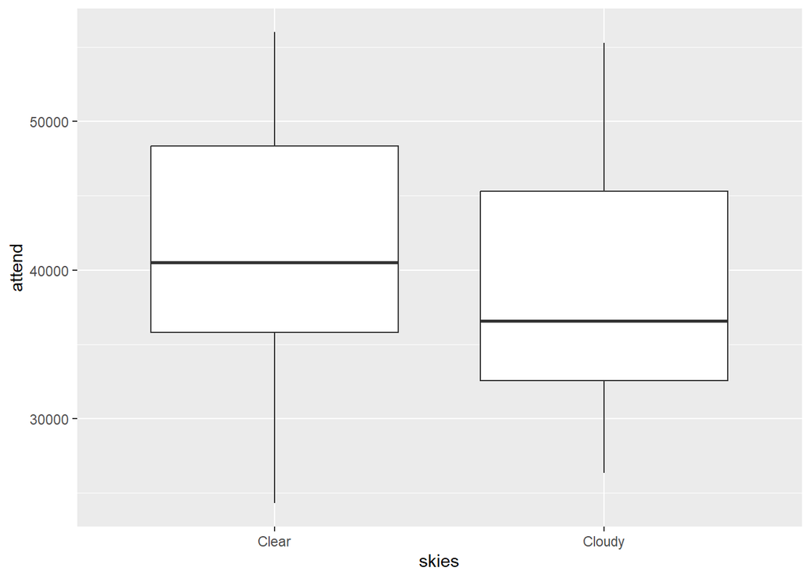

```r
events %>%
  ggplot(aes(skies, attend)) +
  geom_boxplot()
```

The graph suggests that there is very small difference. However, again, to be sure, a Chi-squared test was conducted to check whether there is a connection between sky and attendance numbers.

```r
events %>%
  group_by(skies) %>%
  summarize(avgattend = mean(attend)) %>%
  pull(avgattend) %>% chisq.test()
```

```
##
##  Chi-squared test for given probabilities
##
## data:  .
## X-squared = 107.19, df = 1, p-value < 2.2e-16
```

Somewhat similar to the graph, the results suggest that skies have a impact on attendance. The test showed a connection between sky and attendance numbers. Our p-value is near zero meaning we are confident that sky is related to attendance.

Again, to be sure, a Welch Two Sample t-test was conducted to check whether there is a connection between sky and attendance numbers.

```r
t.test(x=events$attend[events$skies=='Clear'],
       y=events$attend[events$skies=='Cloudy'])
```

```
##
##  Welch Two Sample t-test
##
## data:  events$attend[events$skies == "Clear"] and events$attend[events$skies == "Cloudy"]
## t = 1.2868, df = 27.664, p-value = 0.2088
## alternative hypothesis: true difference in means is not equal to 0
## 95 percent confidence interval:
##  -1741.315  7617.103
## sample estimates:
## mean of x mean of y
##  41729.21  38791.32
```

In contrast to the Chi-squared test, the results suggest that skies have a low impact on attendance. The test showed a disconnection between sky and attendance numbers. Our p-value is more than 0.05, which means we are not totally confident that sky is related or unrelated to attendance. We can be sure after applying F-test.

```r
model_wout_skies <- lm(attend ~ month + day + day_of_week + opponent + temp + day_night + cap + shirt + fireworks + bobblehead, data = events)
anova(lm1, model_wout_skies)
```

```
## Analysis of Variance Table
##
## Model 1: attend ~ month + day + day_of_week + opponent + temp + skies +
##     day_night + cap + shirt + fireworks + bobblehead
## Model 2: attend ~ month + day + day_of_week + opponent + temp + day_night +
##     cap + shirt + fireworks + bobblehead
##   Res.Df        RSS Df Sum of Sq      F Pr(>F)
## 1     44 1572693825
## 2     45 1572775442 -1    -81616 0.0023 0.9621
```

F test’s p value is very close to 1. This result means that two models are not significantly different. So, skies is not an important variable. Therefore, we will not consider skies relations in attendance.

## Temperature

Firstly, we need to visualize the attendance with temperature; then, we can decide whether there was a correlation between the attendance and temperature.

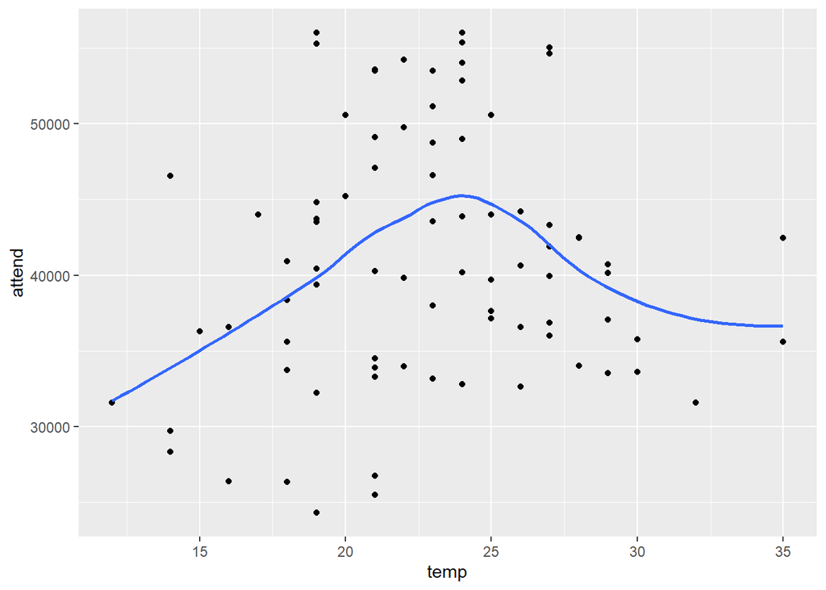

```r
events %>%
  ggplot(aes(temp, attend)) +
  geom_point() +
  geom_smooth(se=FALSE)
```

The graphs suggests a difference, particularly around 23-24 degrees. We can see higher averages of attendance. Therefore, we will consider temperature relations in attendance.

### Temperature with other variables

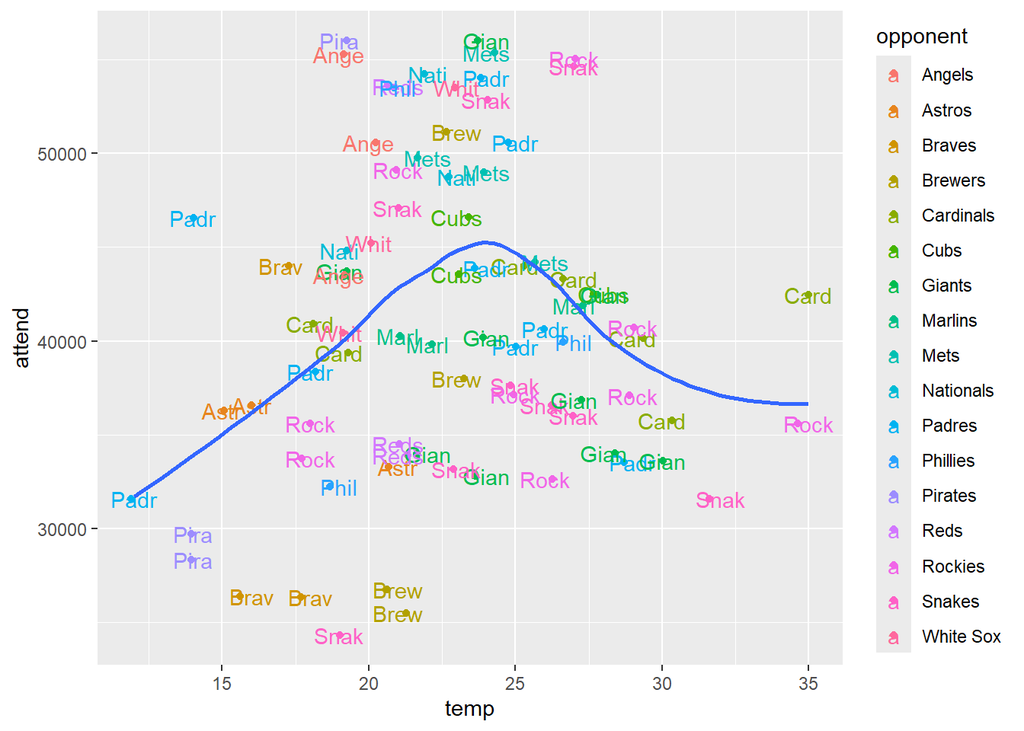

```r
events %>%
  ggplot(aes(temp, attend)) +
  geom_jitter(aes(col = opponent)) +
  geom_text(aes(label = str_sub(opponent, 1,4), col = opponent)) +
  geom_smooth(se = FALSE)
```

Here, we displayed the opponents, temperature, and attendance. Many variances exist, so we should explore this further by considering these variables.

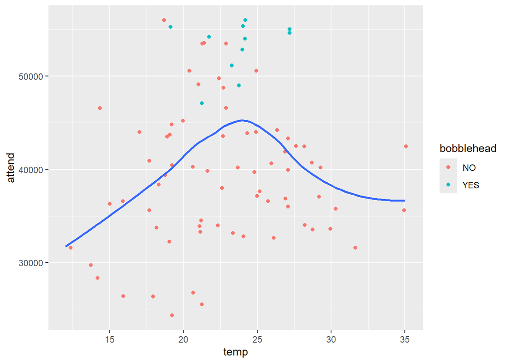

```r
events %>%
  ggplot(aes(temp, attend)) +
  geom_jitter(aes(col = bobblehead)) +
  geom_smooth(se = FALSE)
```

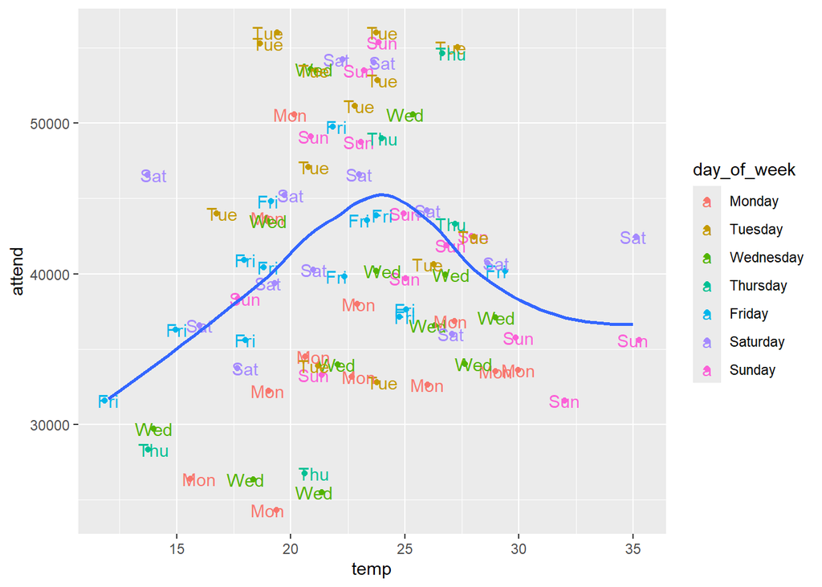

```r
events %>%
  ggplot(aes(temp, attend)) +
  geom_jitter(aes(col = day_of_week)) +
  geom_text(aes(label = str_sub(day_of_week, 1,3), col = day_of_week)) +
  geom_smooth(se = FALSE)
```

Temperature and days of the week of the games played against attendance.

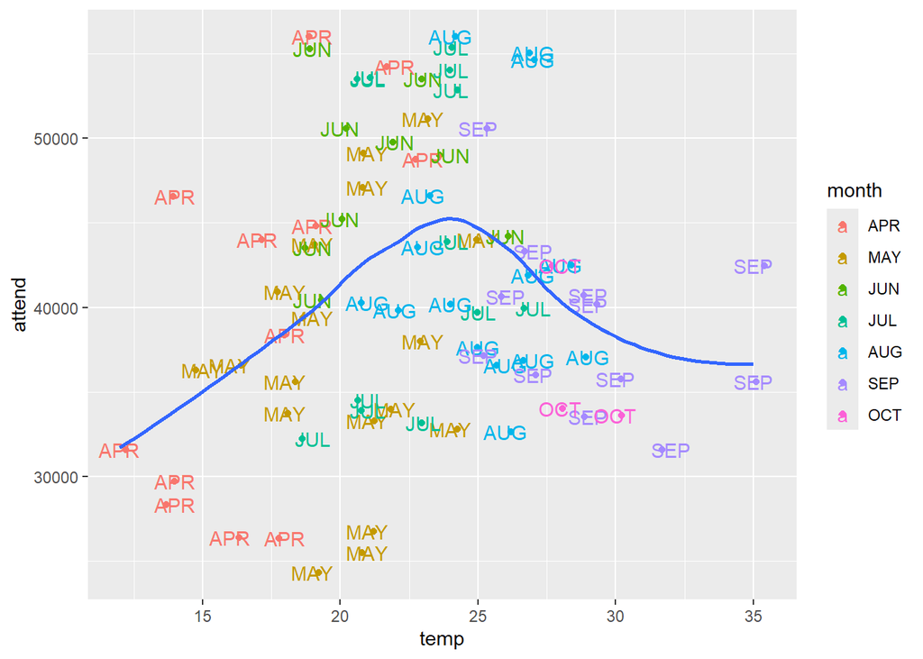

```r
events %>%
  ggplot(aes(temp, attend)) +
  geom_jitter(aes(col = month)) +
  geom_text(aes(label = str_sub(month, 1,3), col = month)) +
  geom_smooth(se = FALSE)
```

Temperature and months of the games played against attendance.

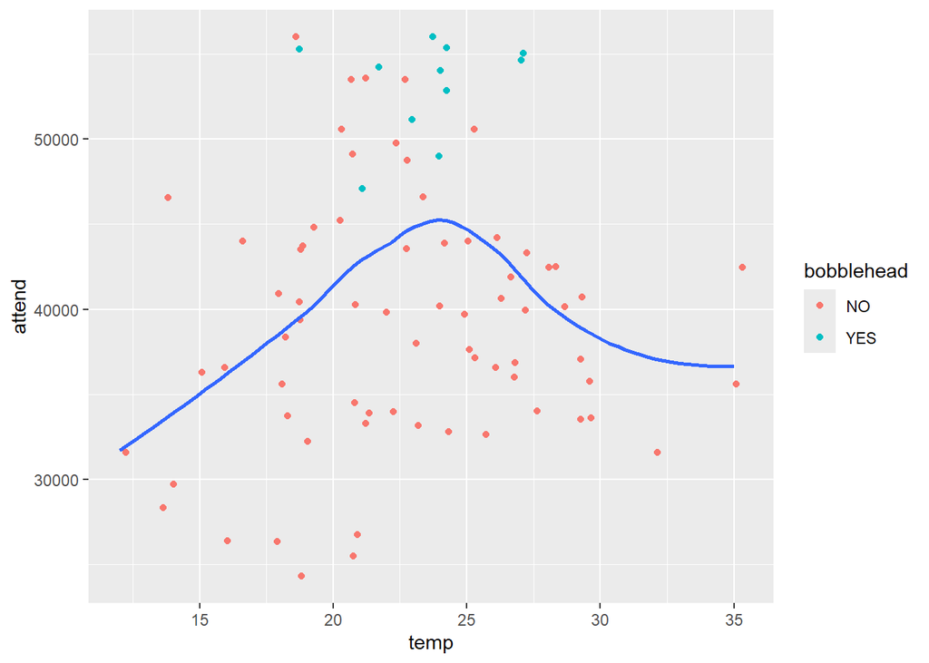

```r
events %>%
  ggplot(aes(temp, attend)) +
  geom_jitter(aes(col = bobblehead)) +
  geom_smooth(se = FALSE)
```

As an another analysis for temp variable, we got a hint from the plot: our shape looks like a -x^2 line. We can play with it to make it more related. Below is the different lines for temp and BIC values of them.

```r
model1<-lm(attend~temp,events)
model2 <- lm(attend~I(temp^2),events)
model3 <- lm(attend~I(temp^2) + I(temp^3),events)
model4 <- lm(attend~I(temp^2) + I(temp^3)+I(temp^4),events)
model5<- lm(attend~poly(temp,2),events)
model6<- lm(attend~poly(temp,3),events)
model7<- lm(attend~poly(temp,4),events)
BIC(model1,model2,model3,model4,model5, model6,model7)
```

```
##        df      BIC
## model1  3 1703.118
## model2  3 1703.678
## model3  4 1699.475
## model4  5 1700.937
## model5  4 1698.193
## model6  5 1702.060
## model7  6 1702.130
```

The model5 has the least BIC value, which is temp^2. Let’s test that model.

```r
summary(model5)
```

```
##
## Call:
## lm(formula = attend ~ poly(temp, 2), data = events)
##
## Residuals:
##      Min       1Q   Median       3Q      Max
## -16727.0  -5940.2   -322.7   5740.4  15256.4
##
## Coefficients:
##                Estimate Std. Error t value Pr(>|t|)
## (Intercept)     41040.1      877.3  46.779  < 2e-16 ***
## poly(temp, 2)1   7213.5     7895.9   0.914  0.36375
## poly(temp, 2)2 -24351.1     7895.9  -3.084  0.00282 **
## ---
## Signif. codes:  0 '***' 0.001 '**' 0.01 '*' 0.05 '.' 0.1 ' ' 1
##
## Residual standard error: 7896 on 78 degrees of freedom
## Multiple R-squared:  0.1171, Adjusted R-squared:  0.09447
## F-statistic: 5.173 on 2 and 78 DF,  p-value: 0.00777
```

As you can see, p-value is less than the indicated level. Now, temp is related to attendance rate. Therefore, we will consider poly(temp,2) in attendance.

## Days and Month

Firstly, we need to visualize the attendance with dates; then, we can decide whether there was a correlation between the attendance.

```r
events %>%
mutate(day_of_week = factor(day_of_week, levels = c("Monday", "Tuesday", "Wednesday", "Thursday", "Friday", "Saturday", "Sunday"))) %>%
count(day_of_week, name = "Number of games") %>%
rename(`Week day`= day_of_week) %>%
pander(caption = "Number of games on week days")
```

Number of games on week days

| Week day | Number of games |
| --- | --- |
| Monday | 12 |
| Tuesday | 13 |
| Wednesday | 12 |
| Thursday | 5 |
| Friday | 13 |
| Saturday | 13 |
| Sunday | 13 |

The games were played uniformly every weekday except Thursday, which has less than other days.

```r
events %>%
mutate(month = factor(month, levels = c("APR", "MAY", "JUN", "JUL", "AUG", "SEP", "OCT"))) %>%
count(month, name = "Number of games") %>%
rename(`Month`= month) %>%
pander(caption = "Number of games across months")
```

Number of games across months

| Month | Number of games |
| --- | --- |
| APR | 12 |
| MAY | 18 |
| JUN | 9 |
| JUL | 12 |
| AUG | 15 |
| SEP | 12 |
| OCT | 3 |

May hosted the most significant number of games, while October the least. June has as much as half of the games in May. The remainder of the months have high and similar game numbers.

Total attendance is plotted against weekday and month in this heatmap. As more people show up, the hues shift from brilliant yellow to dark red. The default heatmap groups weeks and months with comparable attendance by rearranging the rows and columns. Here, we have Saturday, Friday, and Sunday in the weekdays and May, August, and July all together in the months.

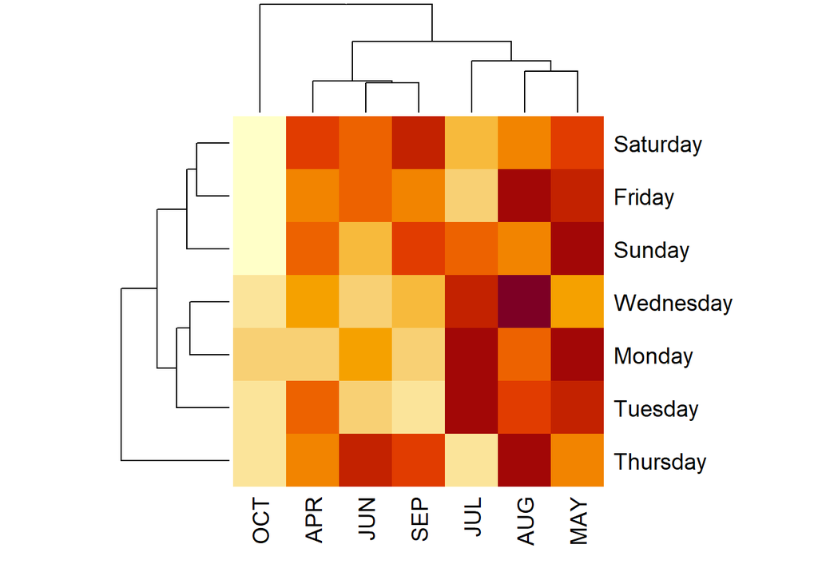

```r
xtabs(attend ~ day_of_week + month, events) %>%
  heatmap()
```

The heatmap suggests a difference. For example, attendance is low in October, and we can see there is higher attendance on Monday, Tuesday, and Wednesday in July. Still, on other days, attendance is low. Therefore, we will consider dates, months, and days relations in attendance. We can use one-way anova test to double check.

```r
anova(lm1)
```

```
## Analysis of Variance Table
##
## Response: attend
##             Df     Sum Sq   Mean Sq F value    Pr(>F)
## month        6  948958117 158159686  4.4249 0.0013911 **
## day          1    1157054   1157054  0.0324 0.8580409
## day_of_week  6 1313796675 218966112  6.1261 0.0001001 ***
## opponent    16  869764162  54360260  1.5209 0.1353920
## temp         1    5406627   5406627  0.1513 0.6992064
## skies        1   23663194  23663194  0.6620 0.4202234
## day_night    1    2002484   2002484  0.0560 0.8139921
## cap          1  210503212 210503212  5.8893 0.0193967 *
## shirt        1   15603535  15603535  0.4365 0.5122382
## fireworks    1  236832794 236832794  6.6260 0.0134937 *
## bobblehead   1  307551208 307551208  8.6045 0.0053078 **
## Residuals   44 1572693825  35743041
## ---
## Signif. codes:  0 '***' 0.001 '**' 0.01 '*' 0.05 '.' 0.1 ' ' 1
```

P-values of both month and day_of_week suggests that they are important. We can also draw a graph to see how attendance varies across the days of the week.

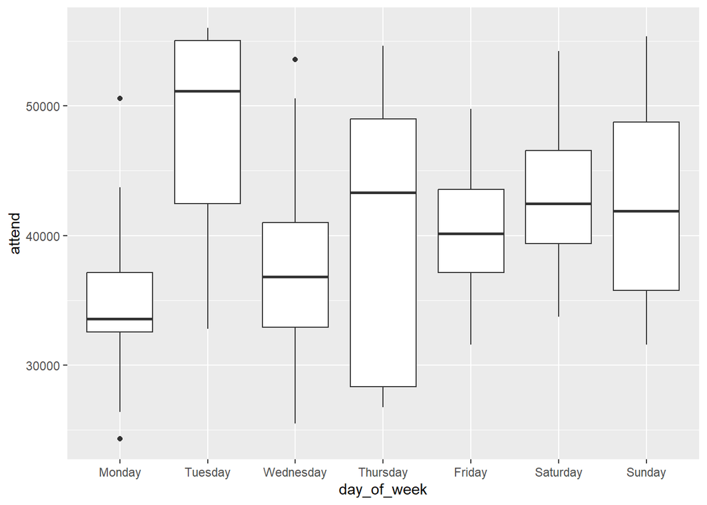

```r
events %>%
  ggplot(aes(day_of_week, attend)) +
  geom_boxplot()
```

Here, we can see that we see a higher average on Tuesdays and a lower average on Mondays. It can be seen in summary of our model with all variables.

```r
lm1 <- lm(attend ~ ., events)
summary(lm1)
```

```
##
## Call:
## lm(formula = attend ~ ., data = events)
##
## Residuals:
##     Min      1Q  Median      3Q     Max
## -9071.5 -3105.3   -83.3  1398.1 12467.6
##
## Coefficients:
##                       Estimate Std. Error t value Pr(>|t|)
## (Intercept)           49144.43   14120.70   3.480  0.00114 **
## monthMAY               4562.82    6161.08   0.741  0.46288
## monthJUN              -2780.38   12052.35  -0.231  0.81862
## monthJUL               4725.36    6220.19   0.760  0.45150
## monthAUG               8631.58    7717.22   1.118  0.26943
## monthSEP               4296.83    7739.53   0.555  0.58158
## monthOCT               6217.52    9532.41   0.652  0.51763
## day                     134.00     141.29   0.948  0.34811
## day_of_weekTuesday     8670.34    2943.86   2.945  0.00514 **
## day_of_weekWednesday      6.94    2764.44   0.003  0.99801
## day_of_weekThursday     460.46    3897.62   0.118  0.90650
## day_of_weekFriday    -18358.17    9210.84  -1.993  0.05247 .
## day_of_weekSaturday    3674.93    3341.26   1.100  0.27737
## day_of_weekSunday       892.73    4810.77   0.186  0.85364
## opponentAstros       -20678.17   14211.96  -1.455  0.15277
## opponentBraves       -18497.20   13741.48  -1.346  0.18517
## opponentBrewers      -22322.21   15155.70  -1.473  0.14791
## opponentCardinals    -12532.09   13146.23  -0.953  0.34565
## opponentCubs         -10529.08   12640.84  -0.833  0.40938
## opponentGiants       -16880.09   13263.72  -1.273  0.20983
## opponentMarlins      -19147.75   13897.97  -1.378  0.17525
## opponentMets          -4234.12    6444.47  -0.657  0.51459
## opponentNationals     -5850.86   13928.61  -0.420  0.67649
## opponentPadres       -11169.54   11310.93  -0.988  0.32880
## opponentPhillies     -13698.94   12586.97  -1.088  0.28237
## opponentPirates      -12451.05   13301.72  -0.936  0.35436
## opponentReds         -16473.41   11915.48  -1.383  0.17379
## opponentRockies      -16964.63   12946.55  -1.310  0.19687
## opponentSnakes       -19919.33   12719.45  -1.566  0.12450
## opponentWhite Sox      -928.32    5735.06  -0.162  0.87215
## temp                    -43.20     436.72  -0.099  0.92166
## skiesCloudy            -114.01    2385.81  -0.048  0.96210
## day_nightNight        -3662.30    3590.06  -1.020  0.31325
## capYES                -6503.20    5866.45  -1.109  0.27365
## shirtYES                949.27    4594.60   0.207  0.83727
## fireworksYES          20200.13    8352.77   2.418  0.01980 *
## bobbleheadYES          9395.63    3203.05   2.933  0.00531 **
## ---
## Signif. codes:  0 '***' 0.001 '**' 0.01 '*' 0.05 '.' 0.1 ' ' 1
##
## Residual standard error: 5979 on 44 degrees of freedom
## Multiple R-squared:  0.7145, Adjusted R-squared:  0.4809
## F-statistic: 3.058 on 36 and 44 DF,  p-value: 0.0002485
```

Only day_of_week Tuesday’s p-value is less than the wanted level.

## Opponents

Firstly, we need to visualize the attendance with opponents; then, we can decide whether there was a correlation between the attendance and opponents.

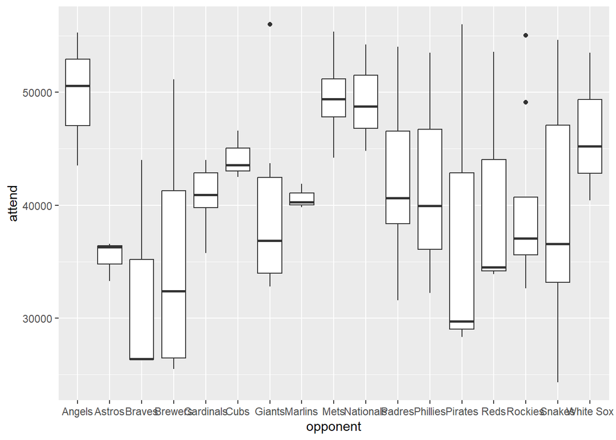

```r
events %>%
  ggplot(aes(opponent, attend)) +
  geom_boxplot()
```

The graph suggests that there is difference. However, again, to be sure, a Chi-squared test was conducted to check whether there is a connection between opponents and attendance numbers.

```r
events %>%
  group_by(opponent) %>%
  summarize(avgattend = mean(attend)) %>%
  pull(avgattend) %>% chisq.test()
```

```
##
##  Chi-squared test for given probabilities
##
## data:  .
## X-squared = 9981.5, df = 16, p-value < 2.2e-16
```

Same as the graph, the results suggest that opponents have a impact on attendance. The test showed a connection between opponents and attendance numbers. Our p-value is near zero meaning we are confident that opponent is related to attendance. We should check other tests.

```r
model_wout_opponent <- lm(attend ~ month + day + day_of_week + temp + skies + day_night + cap + shirt + fireworks + bobblehead, data = events)
anova(lm1, model_wout_opponent)
```

```
## Analysis of Variance Table
##
## Model 1: attend ~ month + day + day_of_week + opponent + temp + skies +
##     day_night + cap + shirt + fireworks + bobblehead
## Model 2: attend ~ month + day + day_of_week + temp + skies + day_night +
##     cap + shirt + fireworks + bobblehead
##   Res.Df        RSS  Df  Sum of Sq     F Pr(>F)
## 1     44 1572693825
## 2     60 2060534523 -16 -487840698 0.853 0.6225
```

Contrary to graph and chi-sq test, anova test suggests that oppenents is not an important variable.

```r
summary(lm1)
```

```
##
## Call:
## lm(formula = attend ~ ., data = events)
##
## Residuals:
##     Min      1Q  Median      3Q     Max
## -9071.5 -3105.3   -83.3  1398.1 12467.6
##
## Coefficients:
##                       Estimate Std. Error t value Pr(>|t|)
## (Intercept)           49144.43   14120.70   3.480  0.00114 **
## monthMAY               4562.82    6161.08   0.741  0.46288
## monthJUN              -2780.38   12052.35  -0.231  0.81862
## monthJUL               4725.36    6220.19   0.760  0.45150
## monthAUG               8631.58    7717.22   1.118  0.26943
## monthSEP               4296.83    7739.53   0.555  0.58158
## monthOCT               6217.52    9532.41   0.652  0.51763
## day                     134.00     141.29   0.948  0.34811
## day_of_weekTuesday     8670.34    2943.86   2.945  0.00514 **
## day_of_weekWednesday      6.94    2764.44   0.003  0.99801
## day_of_weekThursday     460.46    3897.62   0.118  0.90650
## day_of_weekFriday    -18358.17    9210.84  -1.993  0.05247 .
## day_of_weekSaturday    3674.93    3341.26   1.100  0.27737
## day_of_weekSunday       892.73    4810.77   0.186  0.85364
## opponentAstros       -20678.17   14211.96  -1.455  0.15277
## opponentBraves       -18497.20   13741.48  -1.346  0.18517
## opponentBrewers      -22322.21   15155.70  -1.473  0.14791
## opponentCardinals    -12532.09   13146.23  -0.953  0.34565
## opponentCubs         -10529.08   12640.84  -0.833  0.40938
## opponentGiants       -16880.09   13263.72  -1.273  0.20983
## opponentMarlins      -19147.75   13897.97  -1.378  0.17525
## opponentMets          -4234.12    6444.47  -0.657  0.51459
## opponentNationals     -5850.86   13928.61  -0.420  0.67649
## opponentPadres       -11169.54   11310.93  -0.988  0.32880
## opponentPhillies     -13698.94   12586.97  -1.088  0.28237
## opponentPirates      -12451.05   13301.72  -0.936  0.35436
## opponentReds         -16473.41   11915.48  -1.383  0.17379
## opponentRockies      -16964.63   12946.55  -1.310  0.19687
## opponentSnakes       -19919.33   12719.45  -1.566  0.12450
## opponentWhite Sox      -928.32    5735.06  -0.162  0.87215
## temp                    -43.20     436.72  -0.099  0.92166
## skiesCloudy            -114.01    2385.81  -0.048  0.96210
## day_nightNight        -3662.30    3590.06  -1.020  0.31325
## capYES                -6503.20    5866.45  -1.109  0.27365
## shirtYES                949.27    4594.60   0.207  0.83727
## fireworksYES          20200.13    8352.77   2.418  0.01980 *
## bobbleheadYES          9395.63    3203.05   2.933  0.00531 **
## ---
## Signif. codes:  0 '***' 0.001 '**' 0.01 '*' 0.05 '.' 0.1 ' ' 1
##
## Residual standard error: 5979 on 44 degrees of freedom
## Multiple R-squared:  0.7145, Adjusted R-squared:  0.4809
## F-statistic: 3.058 on 36 and 44 DF,  p-value: 0.0002485
```

As it is seen in summary, there is not any opponent row that suggests opponents is an important variable. Therefore, we will not consider opponents relations in attendance.

# Final Model and Validating

In order to make sure that variables do not coincide with other factors in a way that might misguide this test, we need to look at which variables in the dataset affected attendance. This was accomplished by using a multiple regression model that had all the variables and some of them eliminated. A random selection of 85% of the dataset was used to train the model, and the remaining games were used to evaluate how accurate the predictions were.

```r
set.seed(666)
sampleSize <- floor(0.85 * nrow(events))
trainIndex <- sample(seq_len(nrow(events)), size = sampleSize)
train <- events[trainIndex, ]
test <- events[-trainIndex, ]

model <- lm(formula = attend ~ month + day + day_of_week + opponent + temp + skies + day_night + cap + shirt + fireworks + bobblehead, data = train)
summary(model)
```

```
##
## Call:
## lm(formula = attend ~ month + day + day_of_week + opponent +
##     temp + skies + day_night + cap + shirt + fireworks + bobblehead,
##     data = train)
##
## Residuals:
##     Min      1Q  Median      3Q     Max
## -7705.9 -1928.7  -350.7  1541.8 11162.3
##
## Coefficients:
##                      Estimate Std. Error t value Pr(>|t|)
## (Intercept)           69973.8    18936.0   3.695 0.000845 ***
## monthMAY              -3175.9     7155.5  -0.444 0.660244
## monthJUN             -23682.2    16010.9  -1.479 0.149195
## monthJUL              -1771.8     7519.5  -0.236 0.815273
## monthAUG               -764.4     8905.2  -0.086 0.932147
## monthSEP              -1771.3     8858.2  -0.200 0.842813
## monthOCT              -2073.7    10538.9  -0.197 0.845297
## day                     188.6      155.9   1.210 0.235599
## day_of_weekTuesday     7114.1     3161.1   2.250 0.031657 *
## day_of_weekWednesday   1558.5     3212.6   0.485 0.630999
## day_of_weekThursday     885.0     4389.5   0.202 0.841528
## day_of_weekFriday    -16237.3     9641.8  -1.684 0.102216
## day_of_weekSaturday    2480.1     3717.8   0.667 0.509651
## day_of_weekSunday     -7490.6     6923.0  -1.082 0.287602
## opponentAstros       -30048.1    17278.0  -1.739 0.091942 .
## opponentBraves       -38109.0    17420.6  -2.188 0.036365 *
## opponentBrewers      -34357.7    18960.1  -1.812 0.079667 .
## opponentCardinals    -26801.3    16645.2  -1.610 0.117503
## opponentCubs         -18793.9    15460.1  -1.216 0.233300
## opponentGiants       -29261.0    16207.6  -1.805 0.080734 .
## opponentMarlins      -29344.8    16220.0  -1.809 0.080132 .
## opponentMets         -11511.3     8560.7  -1.345 0.188490
## opponentNationals    -26563.8    17760.3  -1.496 0.144847
## opponentPadres       -25208.0    14770.0  -1.707 0.097877 .
## opponentPhillies     -25826.9    15157.7  -1.704 0.098409 .
## opponentPirates      -31407.9    19028.7  -1.651 0.108927
## opponentReds         -28847.1    14690.6  -1.964 0.058595 .
## opponentRockies      -30417.4    15801.5  -1.925 0.063452 .
## opponentSnakes       -33879.8    16148.4  -2.098 0.044149 *
## opponentWhite Sox      1334.6     5864.4   0.228 0.821473
## temp                    130.3      529.8   0.246 0.807352
## skiesCloudy            -470.1     2869.0  -0.164 0.870904
## day_nightNight        -8782.3     5755.1  -1.526 0.137150
## capYES                -5828.2     6404.8  -0.910 0.369863
## shirtYES               2628.8     4755.1   0.553 0.584344
## fireworksYES          17948.0     8643.2   2.077 0.046224 *
## bobbleheadYES         11625.3     3795.6   3.063 0.004507 **
## ---
## Signif. codes:  0 '***' 0.001 '**' 0.01 '*' 0.05 '.' 0.1 ' ' 1
##
## Residual standard error: 5946 on 31 degrees of freedom
## Multiple R-squared:  0.7603, Adjusted R-squared:  0.482
## F-statistic: 2.731 on 36 and 31 DF,  p-value: 0.002717
```

Here, we included all variables to start our improvement of the final model.

The F-statistics p-value is less than 0.05, and then there is a relation between attendance and predictors.

The model is tested and are compared using the Mean Absolute Error. A train sample and a test sample were randomly selected from the dataset using the same seed, ensuring consistency across all model tests.

```r
prediction <- predict(model,test)

mean(abs(prediction-test$attend))
```

```
## [1] 6805.579
```

The tests done between the variables and attendance will be considered the first model to check whether there is a correlation between the two in order to expedite the variable removal process. The accuracy of the model should theoretically increase if a variable is eliminated if it does not correspond with attendance. By removing our unrelated values, we get a final model.

The Mean Absolute Error calculation of the test.

```r
final <- lm(formula = attend ~ month + day + day_of_week
             #+ opponent
             + poly(temp,2)
             #+ skies
             #+ day_night
             #+ cap
             + shirt
             #+ fireworks
             + bobblehead
             , data = train)

finalpred <- predict(final,test)

mean(abs(finalpred-test$attend))
```

```
## [1] 4596.947
```

We see a drop in the MAE of the predictions when the unrelated variables are removed from the initial regression model. These variables are skies, opponent, day or night, cap promotions, and fireworks. Our models prediction is better considering the MAE calculation.

```r
summary(final)
```

```
##
## Call:
## lm(formula = attend ~ month + day + day_of_week + poly(temp,
##     2) + shirt + bobblehead, data = train)
##
## Residuals:
##      Min       1Q   Median       3Q      Max
## -12193.4  -3090.3   -638.6   2088.2  13079.5
##
## Coefficients:
##                      Estimate Std. Error t value Pr(>|t|)
## (Intercept)          36624.31    4047.73   9.048 4.16e-12 ***
## monthMAY             -4342.92    2917.10  -1.489  0.14283
## monthJUN              3295.24    3351.06   0.983  0.33017
## monthJUL               329.83    3525.24   0.094  0.92583
## monthAUG              -758.20    3921.41  -0.193  0.84747
## monthSEP             -2216.25    4841.33  -0.458  0.64910
## monthOCT             -3450.86    6048.18  -0.571  0.57085
## day                    -63.54      97.50  -0.652  0.51755
## day_of_weekTuesday    7096.72    2759.72   2.572  0.01315 *
## day_of_weekWednesday  4119.51    2913.19   1.414  0.16353
## day_of_weekThursday   1606.21    3600.29   0.446  0.65743
## day_of_weekFriday     5984.12    2846.67   2.102  0.04060 *
## day_of_weekSaturday   7938.00    2799.65   2.835  0.00659 **
## day_of_weekSunday     5502.53    2919.14   1.885  0.06525 .
## poly(temp, 2)1        2001.24   12659.63   0.158  0.87503
## poly(temp, 2)2       -8456.19    7610.07  -1.111  0.27180
## shirtYES              5820.85    4021.83   1.447  0.15405
## bobbleheadYES        11540.72    2708.59   4.261 8.99e-05 ***
## ---
## Signif. codes:  0 '***' 0.001 '**' 0.01 '*' 0.05 '.' 0.1 ' ' 1
##
## Residual standard error: 6133 on 50 degrees of freedom
## Multiple R-squared:  0.5887, Adjusted R-squared:  0.4489
## F-statistic:  4.21 on 17 and 50 DF,  p-value: 3.644e-05
```

We will compare our final models diagnostic plots with diagnostic plots of our previous model which has all variables.

Plots of our previous model

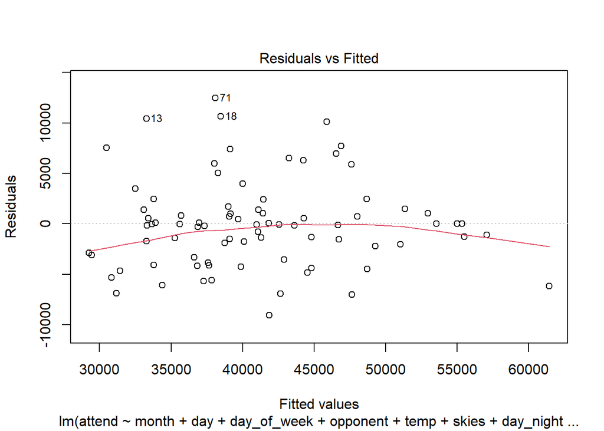

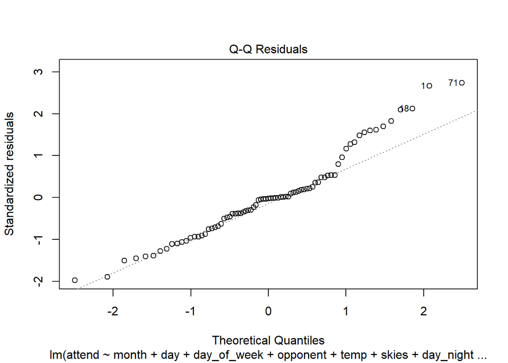

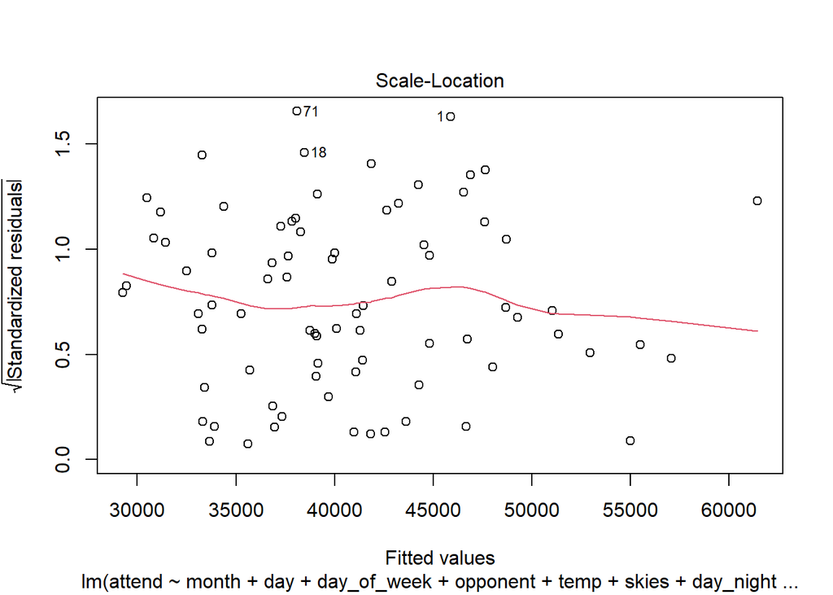

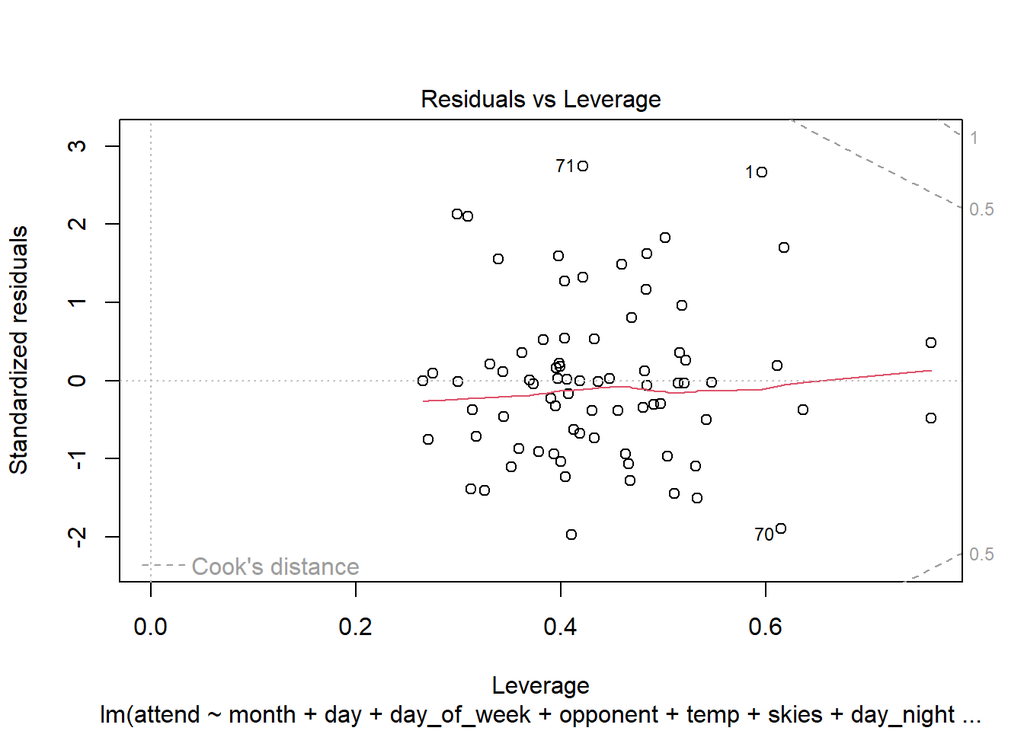

```r
model <- lm(formula = attend ~ month + day + day_of_week + opponent + temp + skies + day_night + cap + shirt + fireworks + bobblehead, data = events)
plot(model)
```

Our final models plot. We can see diagnostics of our final model below.

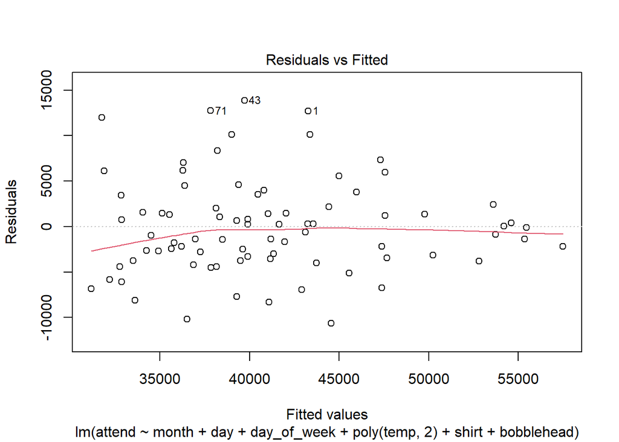

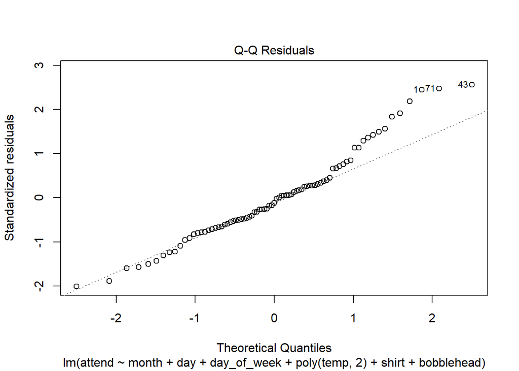

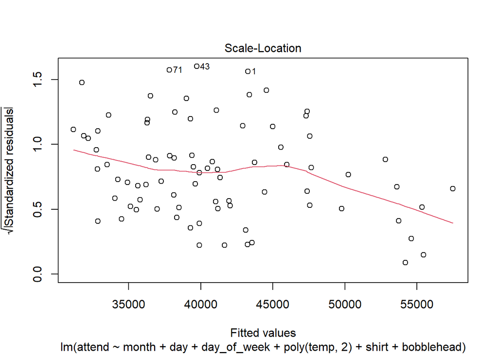

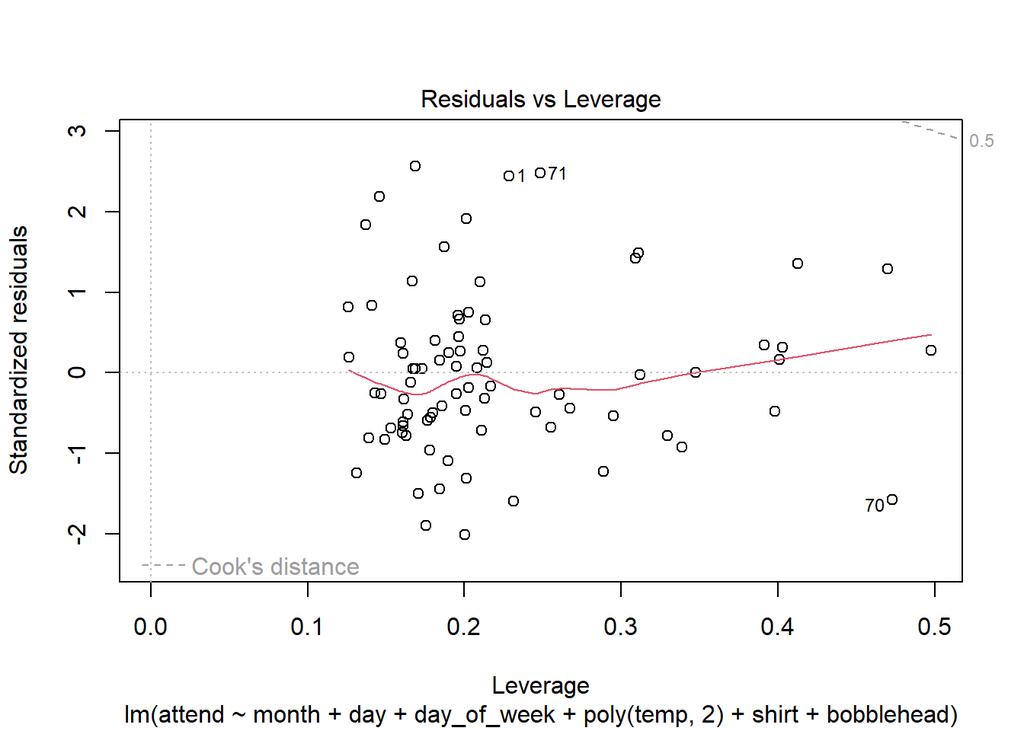

```r
final <- lm(formula = attend ~ month + day + day_of_week
             #+ opponent
             + poly(temp,2)
             #+ skies
             #+ day_night
             #+ cap
             + shirt
             #+ fireworks
             + bobblehead
             , data = events) # make it with full data

plot(final)
```

Fitted value plot of our previous model

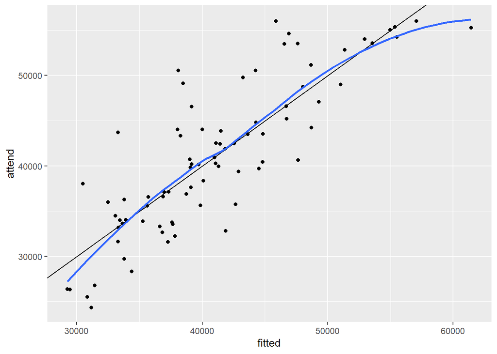

```r
events %>%
  mutate(fitted = fitted(model)) %>%
  ggplot(aes(fitted, attend)) +
  geom_point() +
  geom_abline() +
  geom_smooth(se=FALSE)
```

Fitted value plot of our final model

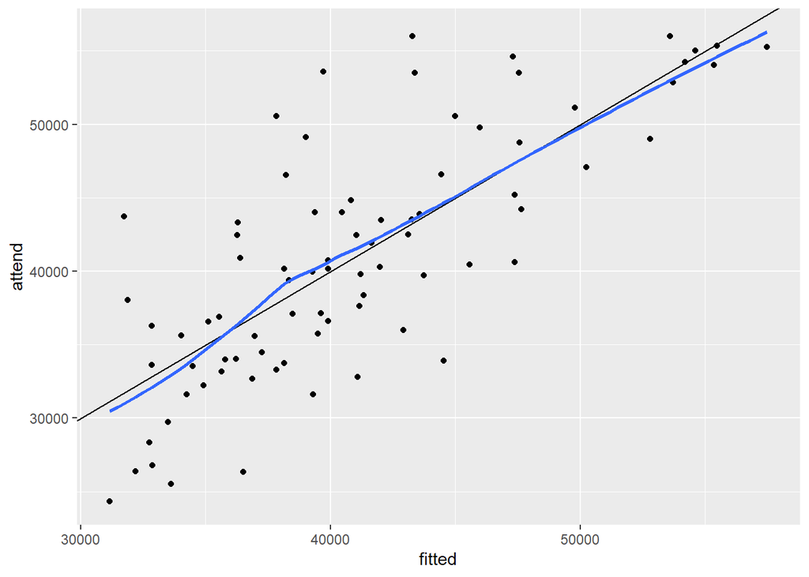

```r
events %>%
  mutate(fitted = fitted(final)) %>%
  ggplot(aes(fitted, attend)) +
  geom_point() +
  geom_abline() +
  geom_smooth(se=FALSE)
```

```r
dbDisconnect(con)
```